# AnaliseEstudantes

Ednei

08 julho, 2024

## Aprendendo R Markdown

O objetivo deste material é apresentar a análise de um *dataframe* utilizando o **RStudio** e alguns packages do R, no caso ggplot2 e dplyr. Ao mesmo tempo que as análises serão desenvolvidas também serão apresentados textos e comentários.

### Conhecendo e ajustando os dados

A primeira coisa a ser feita é olharmos a estrutura da tabela.

```r
 glimpse(dados)
```

```
## Rows: 20
## Columns: 11
## $ Nome                     <chr> "Antonio", "Artur", "Aurea", "Bruno", "Carla"…
## $ Sexo                     <chr> "M", "M", "F", "M", "F", "F", "M", "F", "F", …
## $ Idade                    <int> 22, 16, 15, 16, 14, 19, 34, 29, 27, 19, 22, 1…
## $ Altura..cm.              <int> 169, 174, 163, 164, 168, 165, 177, 159, 162, …
## $ Peso..kg.                <int> 70, 71, 61, 61, 60, 58, 82, 61, 61, 72, 83, 6…
## $ Numero.de.irmãos         <int> 2, 1, 0, 0, 1, 1, 1, 3, 2, 2, 0, 2, 2, 1, 4, …
## $ Cor.de.cabelo            <chr> "castanho", "loiro", "loiro", "castanho", "lo…
## $ Hobby                    <chr> "musica", "musica", "ciclismo", "futebol", "b…
## $ Número.do.sapato         <int> 38, 40, 36, 37, 27, 35, 41, 37, 38, 38, 39, 4…
## $ Manequim                 <int> 38, 40, 42, 42, 40, 36, 44, 40, 42, 44, 46, 4…
## $ Desempenho.em.Matemática <chr> "otimo", "bom", "insuficiente", "otimo", "reg…
```

Podemos verificar que o *dataset* contém 20 casos e 11variáveis, senso as variáveis Sexo, Cor.de.cabelo, Hobby e Desempenho.em.Matemática classificadas de forma inadequada durante importação. Isso porque aparecem como character, ou seja, como strings de texto e na verdade ficaram melhor qualificadas se estivessem como fatores (variáveis categóricas).  
Assim, para procedermos a alteração podemos alterar a classificação das variáveis podemos utilizar o comando mutate do *package* dplyr.

```r
# alterando a classificação das variaveis usando dplyr
dados<- dados %>%
  mutate(Sexo = as.factor(Sexo),
         Hobby = as.factor(Hobby),
         Cor.de.cabelo = as.factor(Cor.de.cabelo))
```

Acontece que se tentarmos alterar o tipo da variável Desempenho.em.Matemática teremos um erro devido a acentuação, desta forma, para resolvermos o problema precisamos alterar o nome da variável.

```r
#alterando o nomes das variáveis
#optei por usar R base porque a alteração me parece mais simples e direta
colnames(dados)[4]<-"Altura"
colnames(dados)[5]<- "Peso"
colnames(dados)[6]<- "NumIrmaos"
colnames(dados)[7]<- "CorCabelo"
colnames(dados)[9]<- "NumSapato"
colnames(dados)[11]<- "DesempenhoMat"

#agora alterar o tipo da variavel desempenho

dados<- dados %>%
  mutate(DesempenhoMat = as.factor(DesempenhoMat))

#verificar as alterações

glimpse(dados)
```

```
## Rows: 20
## Columns: 11
## $ Nome          <chr> "Antonio", "Artur", "Aurea", "Bruno", "Carla", "Claudia"…
## $ Sexo          <fct> M, M, F, M, F, F, M, F, F, F, M, M, F, F, F, M, F, F, F,…
## $ Idade         <int> 22, 16, 15, 16, 14, 19, 34, 29, 27, 19, 22, 18, 17, 16, …
## $ Altura        <int> 169, 174, 163, 164, 168, 165, 177, 159, 162, 169, 173, 1…
## $ Peso          <int> 70, 71, 61, 61, 60, 58, 82, 61, 61, 72, 83, 65, 57, 57, …
## $ NumIrmaos     <int> 2, 1, 0, 0, 1, 1, 1, 3, 2, 2, 0, 2, 2, 1, 4, 3, 2, 0, 1,…
## $ CorCabelo     <fct> castanho, loiro, loiro, castanho, loiro, ruivo, castanho…
## $ Hobby         <fct> musica, musica, ciclismo, futebol, basquete, basquete, f…
## $ NumSapato     <int> 38, 40, 36, 37, 27, 35, 41, 37, 38, 38, 39, 40, 36, 35, …
## $ Manequim      <int> 38, 40, 42, 42, 40, 36, 44, 40, 42, 44, 46, 40, 36, 38, …
## $ DesempenhoMat <fct> otimo, bom, insuficiente, otimo, regular, bom, insuficie…
```

Outra coisa que devemos fazer é olharmos as primeiras linhas do dataset.

```r
head(dados)
```

```
##      Nome Sexo Idade Altura Peso NumIrmaos CorCabelo    Hobby NumSapato
## 1 Antonio    M    22    169   70         2  castanho   musica        38
## 2   Artur    M    16    174   71         1     loiro   musica        40
## 3   Aurea    F    15    163   61         0     loiro ciclismo        36
## 4   Bruno    M    16    164   61         0  castanho  futebol        37
## 5   Carla    F    14    168   60         1     loiro basquete        27
## 6 Claudia    F    19    165   58         1     ruivo basquete        35
##   Manequim DesempenhoMat
## 1       38         otimo
## 2       40           bom
## 3       42  insuficiente
## 4       42         otimo
## 5       40       regular
## 6       36           bom
```

```r
# para inserir linhas em branco pode-se usar <br>
```

### Detalhando os dados com medidas e gráficos

Nesta primeira tabela são apresentadas a altura, idade e peso médio dos participantes

```
## # A tibble: 2 × 4
##   Sexo  IdadeMedia AlturaMedia PesoMedio
##   <fct>      <dbl>       <dbl>     <dbl>
## 1 F           19.8        167.      60.5
## 2 M           20.4        171.      70.1
```

## Gráficos

Na sequência vamos construir alguns gráficos. Primeiro usando o R base e depois usando o ggplot2.

### Gráfico usando o comando plot do R base

Serão apresentados dois gráficos nos quais as diferenças estão relacionadas aos parãmetros incluídos no comando.

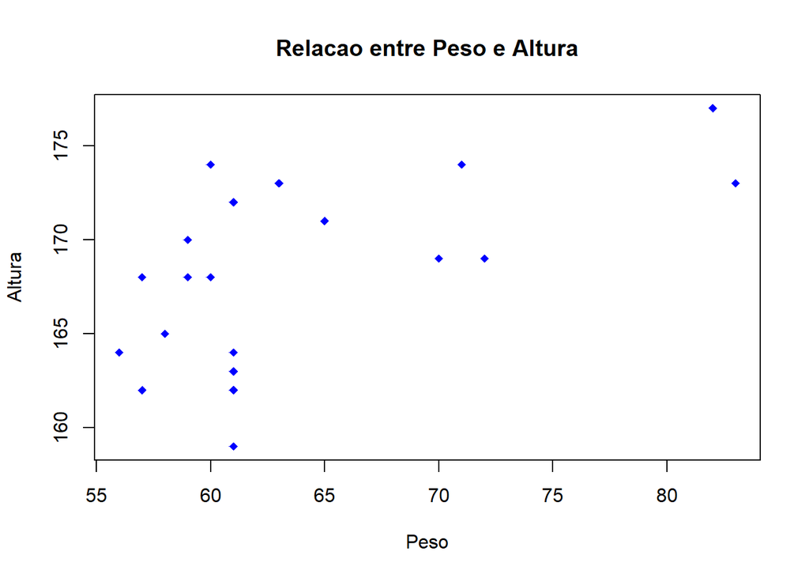

Agora vejamos o mesmo gráfico com mais alguns parâmetros.

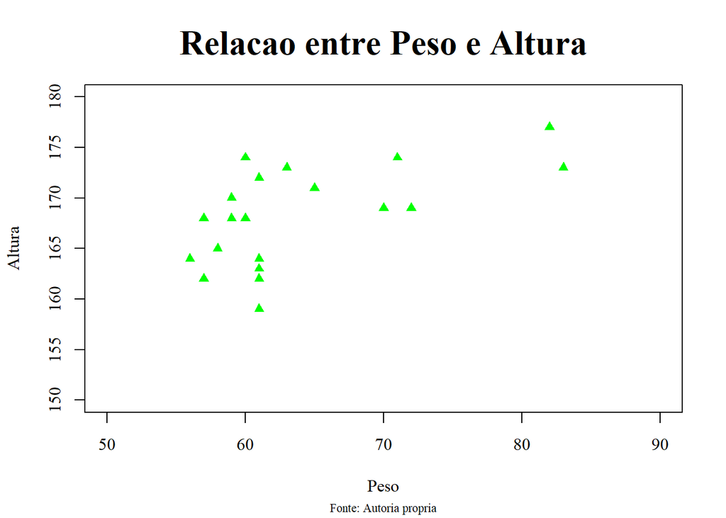

### Gráficos usando o ggplot2

Uma forma muito popular de criar gráficos no R é utilizar o *package* **ggplot2**.

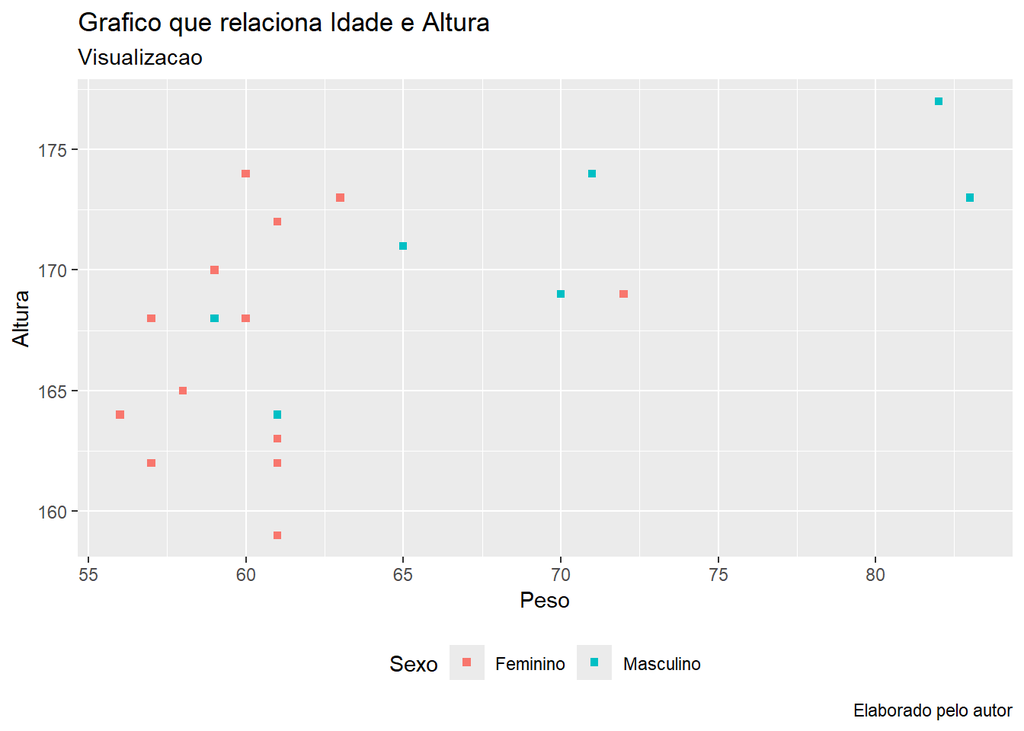

```r
dados %>%
  ggplot(aes(x=Peso, y=Altura, colour = Sexo))+
  geom_point(shape = 15)+ # alterar a forma dos pontos
  labs(title = "Grafico que relaciona Idade e Altura",subtitle = "Visualizacao",
       caption = "Elaborado pelo autor")+ # inserir titulo e subtitulo
  scale_color_discrete(name="Sexo", labels=c("Feminino", "Masculino")) + # alterar os nomes na legenda
  theme(legend.position = "bottom") # alterar a posição da legenda
```

## Modelo Regressão Linear

### Usando R base

Vamos inserir um reta modelando os dados empregados no gráfico acima.

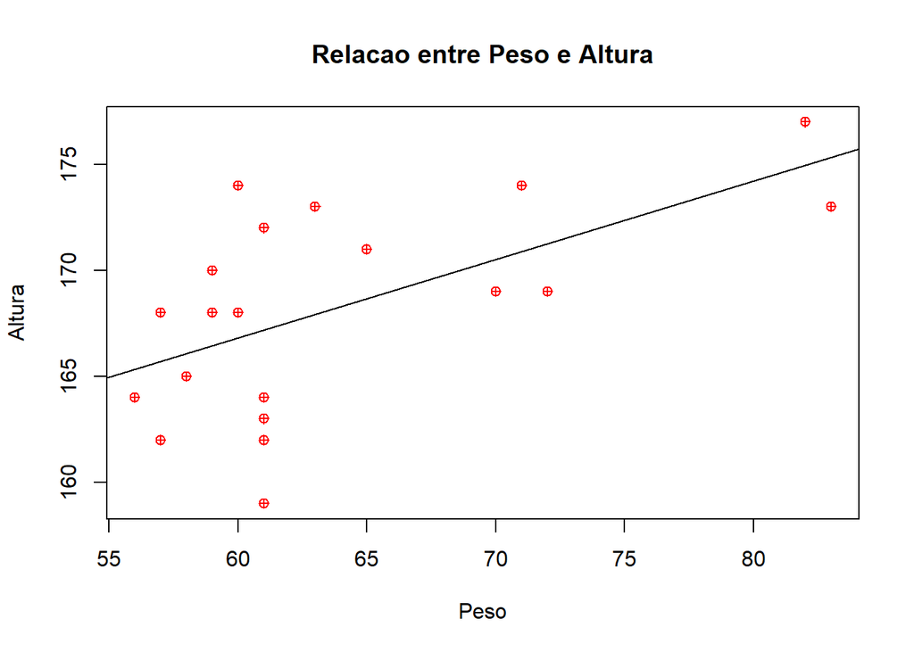

```r
summary(mod1)
```

```
##
## Call:
## lm(formula = dados$Peso ~ dados$Altura)
##
## Residuals:
##    Min     1Q Median     3Q    Max
## -9.320 -4.801 -1.185  3.681 14.631
##
## Coefficients:
##              Estimate Std. Error t value Pr(>|t|)
## (Intercept)  -96.2063    51.1768  -1.880   0.0764 .
## dados$Altura   0.9513     0.3041   3.129   0.0058 **
## ---
## Signif. codes:  0 '***' 0.001 '**' 0.01 '*' 0.05 '.' 0.1 ' ' 1
##
## Residual standard error: 6.462 on 18 degrees of freedom
## Multiple R-squared:  0.3523, Adjusted R-squared:  0.3163
## F-statistic: 9.789 on 1 and 18 DF,  p-value: 0.005802
```

### Usando Ggplot2

Agora fazendo a mesma regressão no ggplot2.

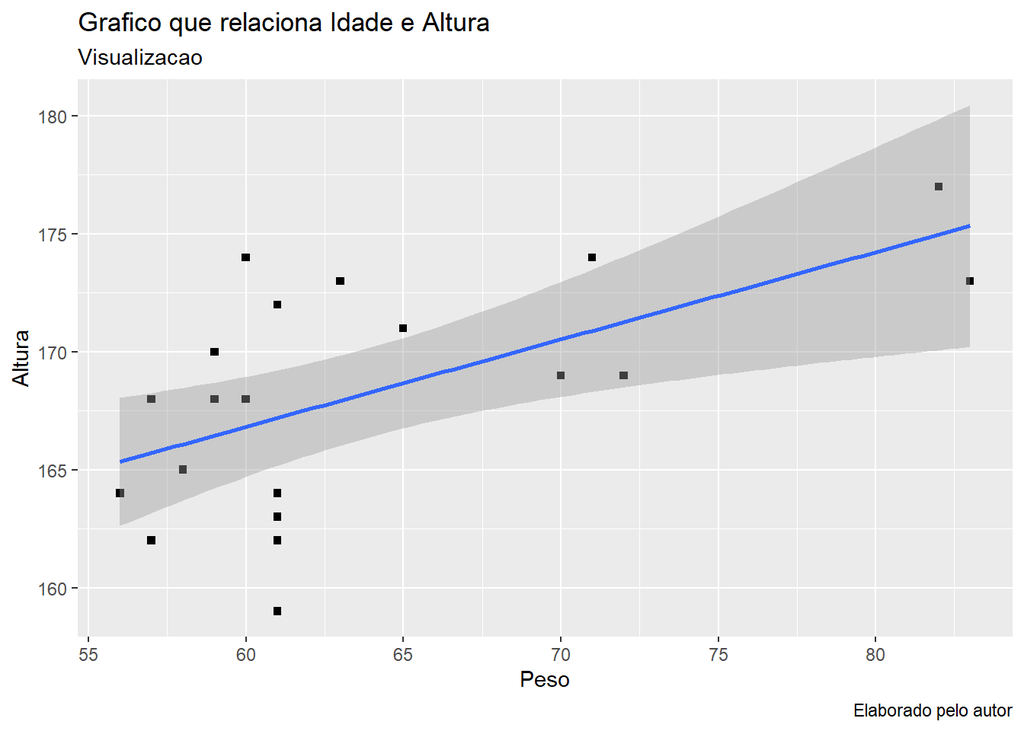

```r
dados %>%
  ggplot(aes(x=Peso, y=Altura))+
  geom_point(shape = 15)+
  geom_smooth(method = "lm")+
  labs(title = "Grafico que relaciona Idade e Altura",subtitle = "Visualizacao",
       caption = "Elaborado pelo autor")+
  scale_color_discrete(name="Sexo", labels=c("Feminino", "Masculino")) +
  theme(legend.position = "bottom")
```

## Gráficos de Colunas ou Barras

Inicalmente se construirá um gráfico de barras/colunas que tabelam uma variável categórica e depois exibem o gráfico e, na sequência se procederá a construção de um outro gráfico no qual se relacionará duas variáveis, uma quantitativa e outra categórica.

### Gráfico de Colunas com R base

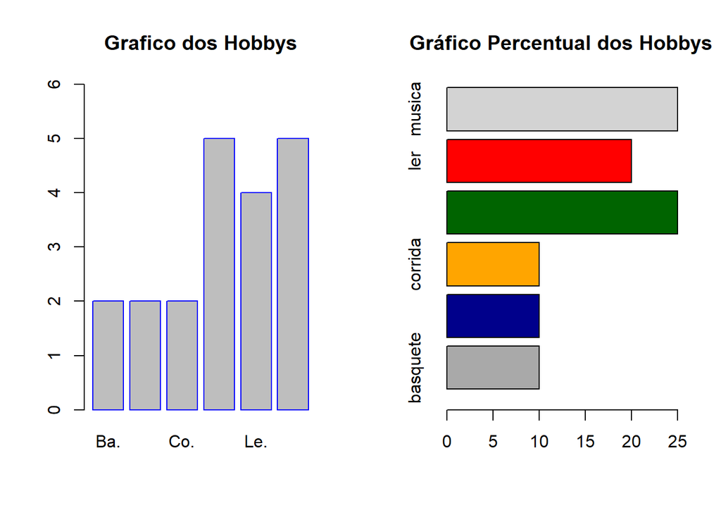

```r
par(mfrow=c(1,2)) # dividir a tela em 1 linha e 2 colunas

barplot(table(dados$Hobby), main="Grafico dos Hobbys", ylim = c(0,6), border = "blue",
        names.arg = c("Ba.", "Ci.", "Co.", "Fu.", "Le.", "Mu.")) # grafico de colunas
# seria possivel armazenar dos gerados por table em um variavel

barplot(prop.table(table(dados$Hobby))*100, main="Gráfico Percentual dos Hobbys", ylim = c(0,7), col = c("darkgrey", "darkblue", "orange", "darkgreen", "red","lightgrey"), horiz = TRUE) # grafico de colunas percentual
```

```r
par(mfrow=c(1,1)) # retornar ao padrao da tela
```

### Gráfico de Colunas usando ggplot2

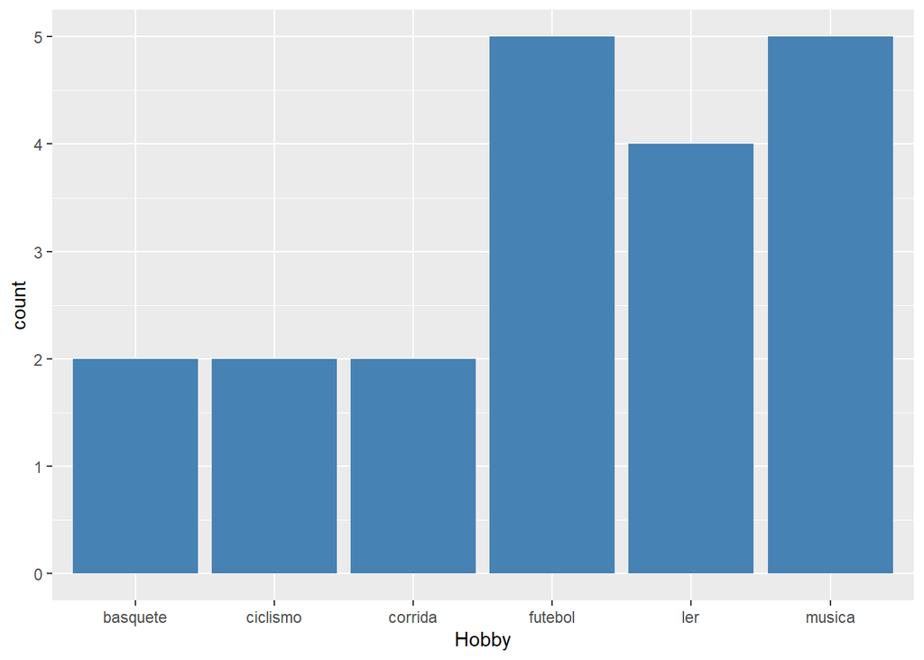

```r
dados %>%
  ggplot(aes(Hobby))+
  geom_bar(fill="steelblue")
```

```r
# para girar as colunas basta acrescentar coord_flip()
```

### Gráficos de Colunas/Barras para uma variável quantitativa e outro categórica

Agora se construirá um outro gráfico de colunas/barras mas desta vez se utilizará uma variável quantitativa e outra categórica.

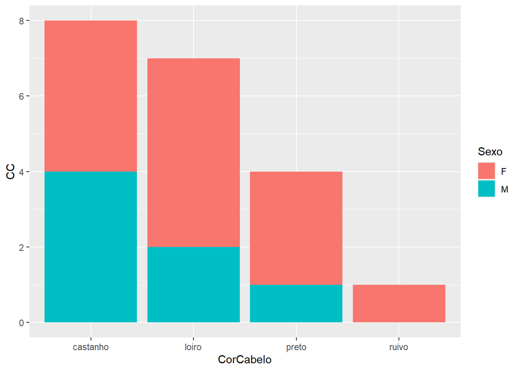

```r
dados %>%
  group_by(CorCabelo, Sexo) %>%
  summarise(CC = n()) %>%
  ggplot(aes(x=CorCabelo, y=CC, fill = Sexo))+
  geom_col()
```

Também podemos exibir as colunas lado a lado. Note que neste caso foi necessário criar um outro dataframe pois a combinação das variáveis cor de cabelo e sexo, para os individudos do sexo masculino ruivos tem contagem zero. Desta forma, quando o gráfico é gerado diretamente pelo Ggplot2 as duas subcategorias masculino e feminino são unidas gerando uma coluna com o dobro do tamanho.

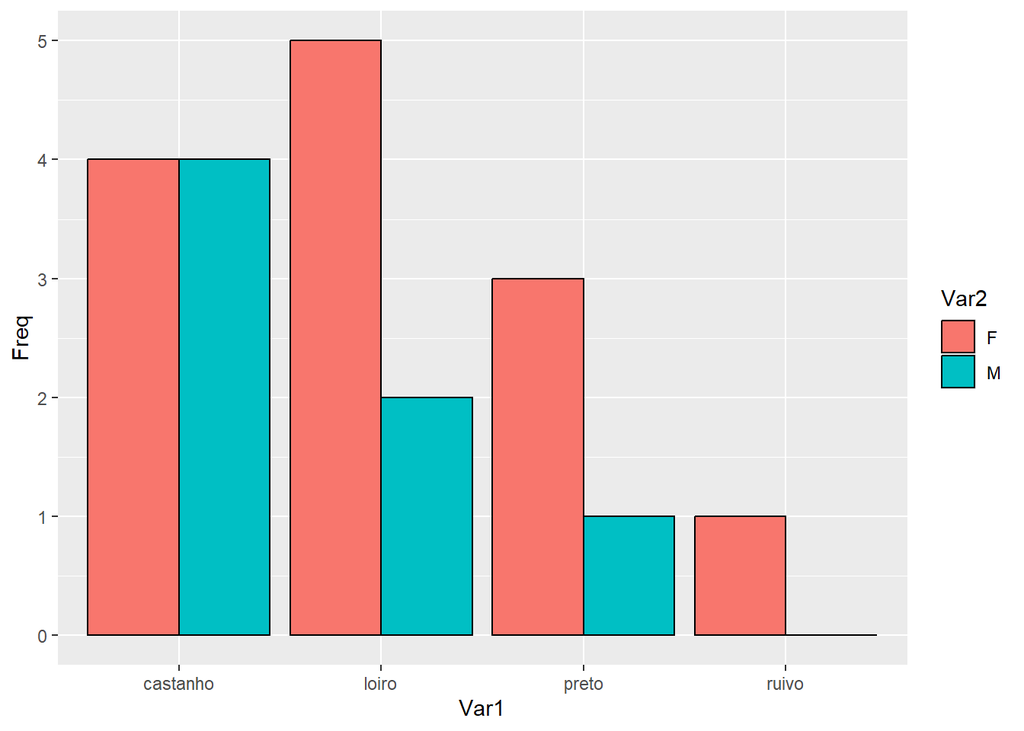

```r
CC<- table(dados$CorCabelo, dados$Sexo)
CC<- as.data.frame(CC)

CC %>%
  ggplot(aes(x=Var1, y=Freq, fill = Var2))+
  geom_col(position = "dodge", color="black", size= 0.5)
```

Continua…

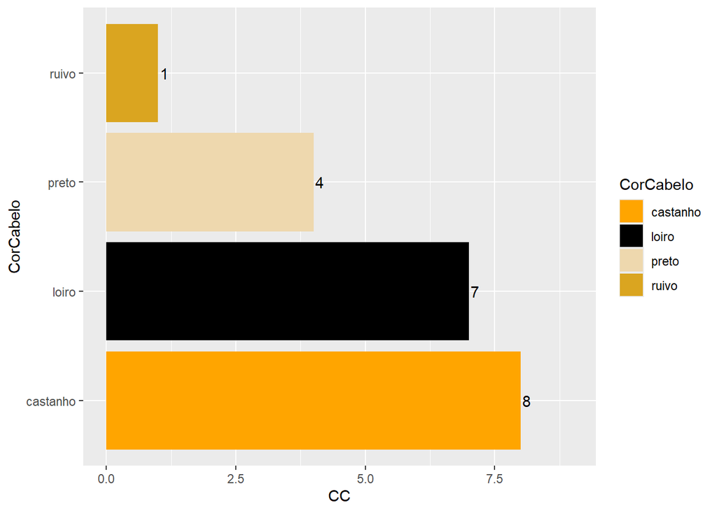

```r
dados %>%
  group_by(CorCabelo) %>%
  summarise(CC = n()) %>%
  ggplot(aes(x=CorCabelo, y=CC, fill = CorCabelo))+
  geom_col()+
  scale_fill_manual(values = c("orange1", "black", "wheat2", "goldenrod"))+
  coord_flip()+
  geom_text(aes(label = CC), hjust= -0.2)+
  ylim(c(0,9))
```